# HS project

Welcome

2025-06-04

This site gathers and describes all scripts used for the analysis of single-cell RNA sequencing (scRNA-Seq), from raw count matrices to figure presented in the publication.

Onfroy *et al.*, Hair follicle stem cell fate supports distinct clinical endotypes in *Hidradenitis Suppurativa*,  
bioRxiv; doi: 10.1101/2025.05.28.656362

All computational analyses were conducted using R language within RStudio. R Markdown (RMD) files were compiled to generate static HTML files, which are shared through this site. Once a file is open, a link in the top left corner enables to open it in a new tab. In the top right corner, the button “Code” allows to download the RMD file behind the HTML.

# Data availability

| Content | Availability |
| --- | --- |
| scRNA-Seq data | GEO, accession number GSE273109 |
| R Markdown files | GitHub repository hosting this website |
| Singularity container | Zenodo, record ID 15512051 |

One scRNA-Seq dataset corresponds to hair follicles from one human individual, either a HS patient or healthy donor. For each dataset, the following files are accessible at the accession number **GSE273109** in the Gene Expression Omnibus (GEO) repository (link above):

- FASTQ files: four R1 (cell barcode + UMI), four R2 (biological information) and four I1 (sample index). One R1-R2-I1 group of files correspond to one lane in the sequencer. Each sample was sequenced once.
- `features.tsv.gz`, `barcodes.tsv.gz` and `matrix.mtx.gz`: raw count matrix, output by Cell Ranger software version 3.1.0, using the hg19 reference transcriptome.
- `sobj_filtered.rds`: Seurat object with cells filtered based on quality metrics. The object format is issued from *Seurat* package version 3.1.5.

# Data presentation

Seven original datasets were analyzed in the article, whose main characteristics are described in the table below.

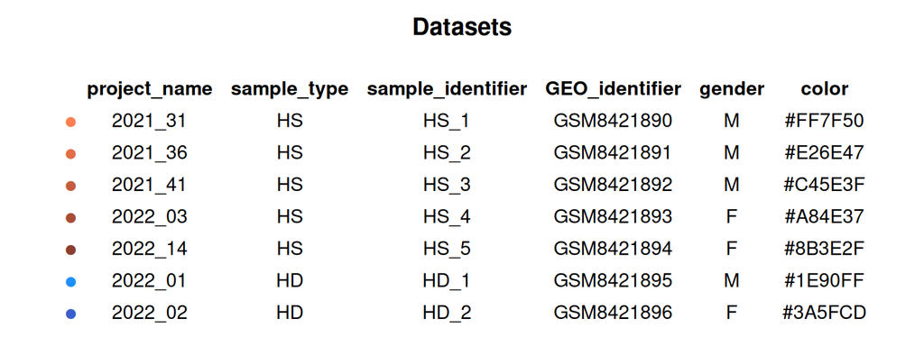

# Analysis framework

Analyses were conducted in specific directories, organised in a tree as shown below:

```bash
cat tree.txt
```

```
## # tree -n -P "*Rmd" ./.. > tree.txt
##
## ./..
## ├── 0_intro
## │   └── welcome.Rmd
## ├── 1_metadata
## │   └── 1_build_metadata.Rmd
## ├── 2_individual
## │   ├── 1_make_individual.Rmd
## │   ├── datasets
## │   └── input
## │       ├── 2021_31
## │       ├── 2021_36
## │       ├── 2021_41
## │       ├── 2022_01
## │       ├── 2022_02
## │       ├── 2022_03
## │       └── 2022_14
## ├── 3_combined
## │   ├── 1_combined_all.Rmd
## │   ├── 2_combined_three_data.Rmd
## │   └── 3_ors_ifeb_markers.Rmd
## ├── 4_zoom
## │   ├── 1_zoom_immune
## │   │   ├── 1_zoom_immune_dataset.Rmd
## │   │   └── 2_zoom_immune_analysis.Rmd
## │   ├── 2_zoom_hfsc
## │   │   ├── 1_zoom_hfsc_dataset.Rmd
## │   │   └── 2_zoom_hfsc_analysis.Rmd
## │   ├── 3_zoom_ors_ifeb
## │   │   ├── 1_zoom_ors_ifeb_dataset.Rmd
## │   │   └── 2_zoom_ors_ifeb_analysis.Rmd
## │   ├── 4_zoom_ifegs
## │   │   ├── 1_zoom_ifegs_dataset.Rmd
## │   │   └── 2_zoom_ifegs_analysis.Rmd
## │   ├── 5_zoom_non_matrix
## │   │   ├── 1_zoom_non_matrix_dataset.Rmd
## │   │   ├── 2_trajectory_tinga.Rmd
## │   │   └── 3_trajectory_slingshot.Rmd
## │   └── 6_zoom_matrix
```

[output cut: 35 more lines]

```
## │   │       └── GSM3717038
## │   ├── 3_combined
## │   │   └── 1_combined_all.Rmd
## │   └── 4_ors_ifeb
## │       ├── 1_zoom_ors_ifeb_dataset.Rmd
## │       └── 2_zoom_ors_ifeb_analysis.Rmd
## ├── 7_figures
## │   ├── data
## │   ├── figures_detail
## │   └── figures.Rmd
## └── index_layout
##     ├── logo
##     └── pages
##
## 55 directories, 31 files
```

Note that the menu on the left follows almost the same structure.

# RMD knitting

R Markdown (RMD) notebooks were developed within R Studio. To ensure the reproducibility of all the analyses from the raw count matrices to the final figures and results, the RMD files were compiled using a Singularity container, to generate the HTML pages presented here. Excepting the notebooks focusing on individual dataset, all notebooks are parameter-free, so that they can be compiled using the same command. The following template was used:

```bash
file="FILE_NAME"
singularity exec \
--bind /home \
/path/to/singularity/image/singularity.simg \
Rscript -e "rmarkdown::render(input = '${file}.Rmd', output_file = '${file}.html')"
```

The `1_make_individual` notebook requires one parameter called `sample_name` and corresponding to the project name as described earlier. Project name should be defined in the metadata file, with color, sample identifier and so on, because these information will be used to annotate the individual datasets. Project name should also correspond to a folder name in the input folder. To generate the individual datasets, we thus use the following bash commands:

```bash
file="1_make_individual"
for sample in $(ls ./2_individual/input/)
do
echo $sample
singularity exec \
--bind /home \
/path/to/singularity/image/singularity.simg \
Rscript -e "rmarkdown::render(input = './1_make_individual.Rmd',
                              output_file = './${sample}.html',
                              params = list(sample_name = '${sample}'))"
done
```

Since R libraries are not located at the same location within the Singularity container or on the local machine, we add the `.libPaths()` R command at the beginning of each notebook. In the compiled HTML file, we thus can easily check if the notebook was compiled through the container or not.

# Index page

The static website was built using OrganizeHTML (DOI: 10.5281/zenodo.14505634)

–end–